# Practical 5: Generalized linear models

## Model 2

Now we add the categorical predictor `topo` to account for differences in location.

```r
default_prior(Predation ~ seed + topo,
              family = bernoulli(link=logit),
              data = df )
```

```
                prior     class  coef group resp dpar nlpar lb ub tag       source
               (flat)         b                                            default
               (flat)         b  seed                                 (vectorized)
               (flat)         b topo2                                 (vectorized)
               (flat)         b topo3                                 (vectorized)
               (flat)         b topo4                                 (vectorized)
 student_t(3, 0, 2.5) Intercept                                            default
```

We assign priors for seed slope (continuous) and topo-differences (categorical)

```r
df.seed.2 = brm(Predation ~ seed + topo,
                family = bernoulli(link=logit),
                prior =
                  prior(normal(0,2), class=b) + # for all effects
                  prior(normal(1,1), class=b, coef=seed), # just for seed
                data = df )
```

Check convergence

```r
summary(df.seed.2, prior=T)
```

```
 Family: bernoulli
  Links: mu = logit
Formula: Predation ~ seed + topo
   Data: df (Number of observations: 1142)
  Draws: 4 chains, each with iter = 2000; warmup = 1000; thin = 1;
         total post-warmup draws = 4000

Priors:
b ~ normal(0, 2)
b_seed ~ normal(1, 1)
Intercept ~ student_t(3, 0, 2.5)

Regression Coefficients:
          Estimate Est.Error l-95% CI u-95% CI Rhat Bulk_ESS Tail_ESS
Intercept    -1.02      0.15    -1.32    -0.74 1.00     4301     3184
seed          1.15      0.10     0.97     1.35 1.00     2927     2778
topo2        -1.94      0.28    -2.52    -1.39 1.00     2927     2120
topo3        -1.57      0.26    -2.09    -1.07 1.00     3231     3086
topo4        -2.00      0.29    -2.58    -1.45 1.00     3392     2937

Draws were sampled using sampling(NUTS). For each parameter, Bulk_ESS
and Tail_ESS are effective sample size measures, and Rhat is the potential
scale reduction factor on split chains (at convergence, Rhat = 1).
```

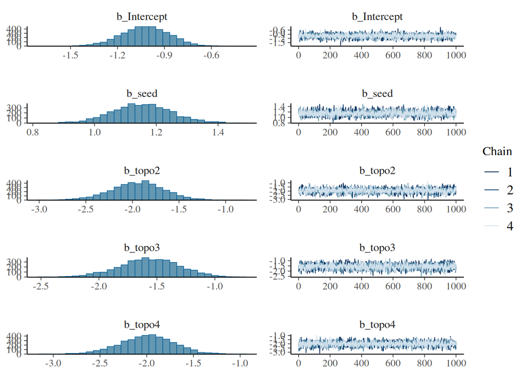

```r
plot(df.seed.2)
```

We see there is substantial variation between locations (`topo`)

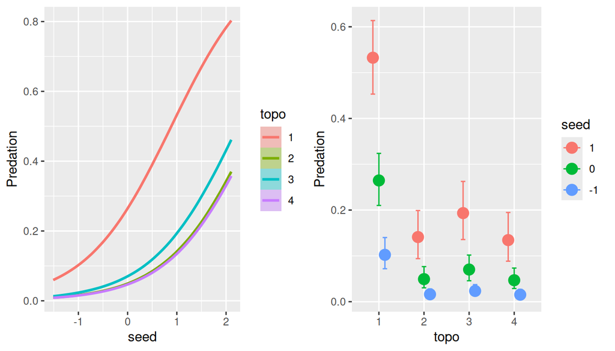

```r
p1 = plot(conditional_effects(df.seed.2,
                              effect="seed:topo",
                              prob=0),
          plot=F)
p2 = plot(conditional_effects(df.seed.2,
                              effect="topo:seed"),
          plot=F)
plot_grid(p1[[1]],p2[[1]])
```

This `~seed+topo` (generalized) ANCOVA without interaction produces parallel fitted values (intercept varies with `topo`) on the linear scale (`method="posterior_linpred"`).

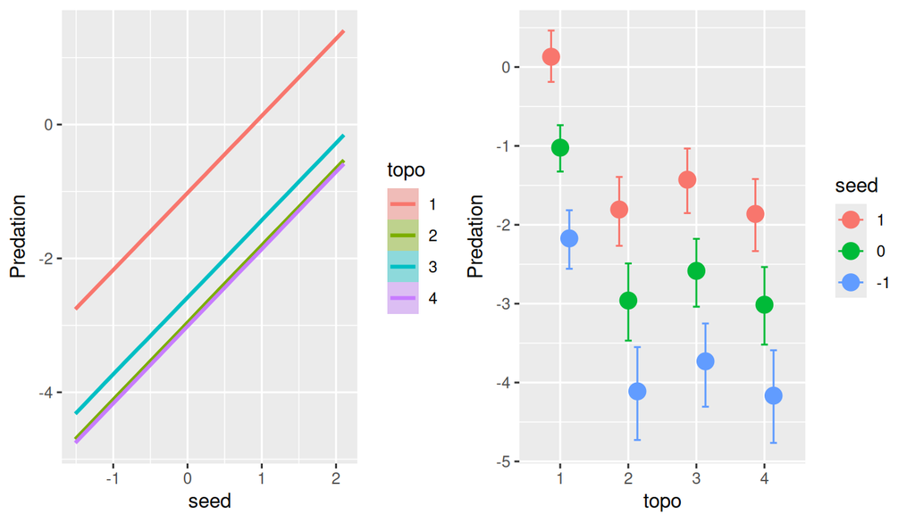

```r
p1 = plot(conditional_effects(df.seed.2,
                              effect="seed:topo",
                              prob=0,
                              method="posterior_linpred"),
          plot=F)
p2 = plot(conditional_effects(df.seed.2,
                              effect="topo:seed",
                              method="posterior_linpred"),
          plot=F)
plot_grid(p1[[1]],p2[[1]])
```

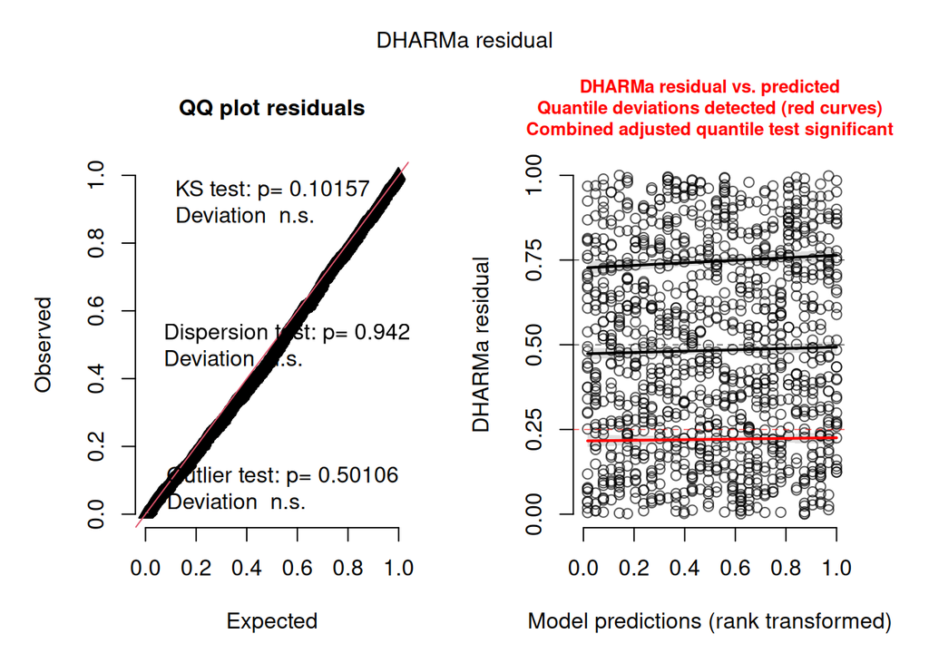

```r
dh_check_brms(df.seed.2)
```

Residuals are looking better now!

Model selection suggests including `topo` improves the model.

```r
LOO(df.seed.1, df.seed.2)
```

```
          elpd_diff se_diff
df.seed.2   0.0       0.0
df.seed.1 -40.3       9.3
```

## Model 3

Now we add sampling campaign (`time`) as a factorial predictor.

```r
df.seed.3 = brm(Predation ~ seed + topo + time,
                family = bernoulli(link=logit),
                prior =
                  prior(normal(0,2), class=b) + # for all effects
                  prior(normal(1,1), class=b, coef=seed), # just for seed
                data = df )
```

Check convergence

```r
summary(df.seed.3, prior=T)
```

```
 Family: bernoulli
  Links: mu = logit
Formula: Predation ~ seed + topo + time
   Data: df (Number of observations: 1142)
  Draws: 4 chains, each with iter = 2000; warmup = 1000; thin = 1;
         total post-warmup draws = 4000

Priors:
b ~ normal(0, 2)
b_seed ~ normal(1, 1)
Intercept ~ student_t(3, 0, 2.5)

Regression Coefficients:
          Estimate Est.Error l-95% CI u-95% CI Rhat Bulk_ESS Tail_ESS
Intercept    -3.19      0.43    -4.07    -2.39 1.00     1418     1671
seed          1.25      0.10     1.05     1.45 1.00     2017     2646
topo2        -2.11      0.29    -2.69    -1.56 1.00     2774     2972
topo3        -1.70      0.26    -2.23    -1.20 1.00     3010     3333
topo4        -2.17      0.29    -2.75    -1.61 1.00     2671     2714
time2         1.85      0.49     0.92     2.84 1.00     1642     1785
time3         2.22      0.48     1.32     3.19 1.00     1594     1777
time4         2.69      0.48     1.78     3.66 1.00     1497     1952
time5         2.54      0.48     1.65     3.49 1.00     1550     1941
time6         2.74      0.48     1.85     3.70 1.00     1541     2034

Draws were sampled using sampling(NUTS). For each parameter, Bulk_ESS
and Tail_ESS are effective sample size measures, and Rhat is the potential
scale reduction factor on split chains (at convergence, Rhat = 1).
```

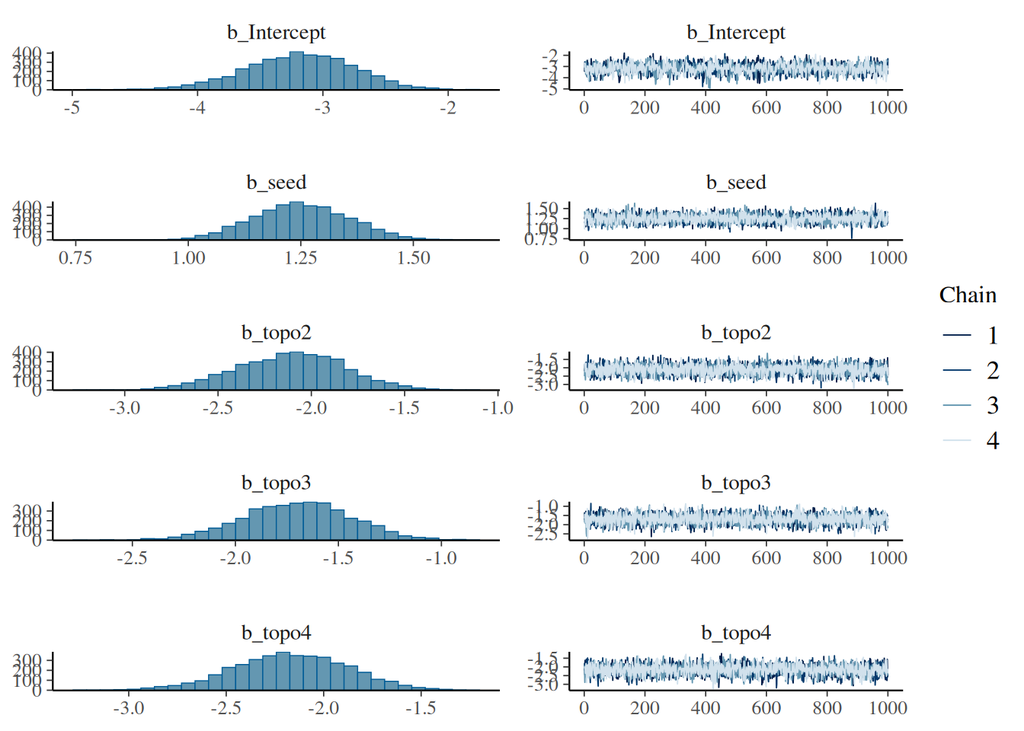

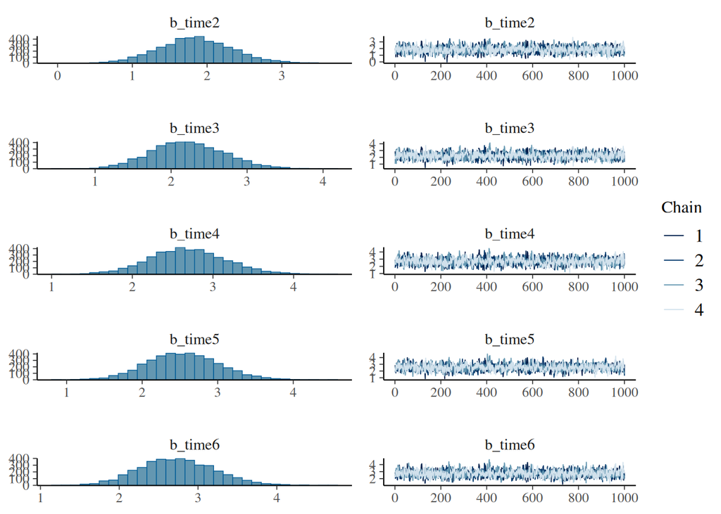

```r
plot(df.seed.3)
```

With 3 predictors, plotting conditional effects is getting more complicated, but the function can handle it.

The same plot as in Model 2, but when we don’t specify the 3rd predictor, fitted values are shown at its reference level (`time=1`)

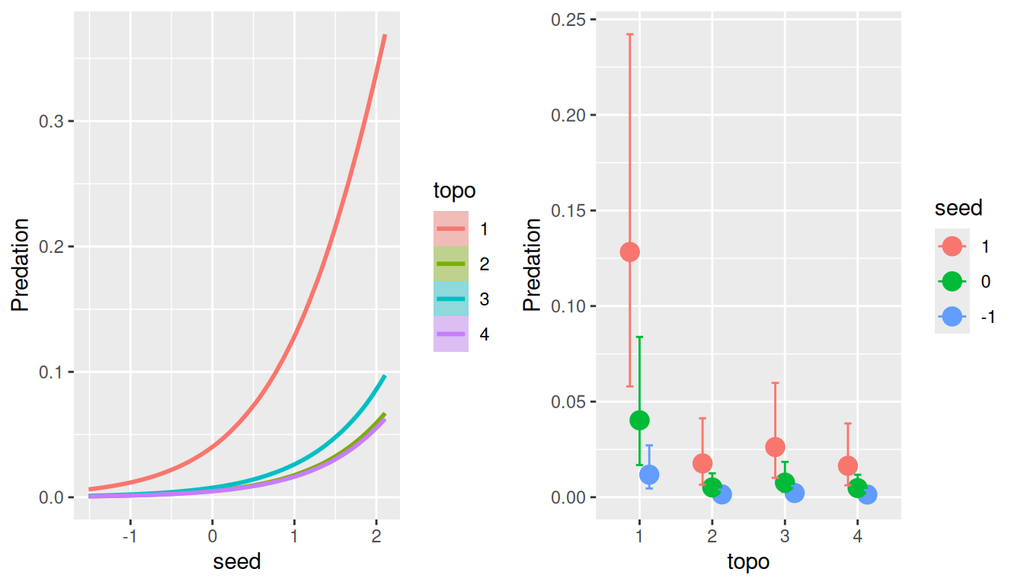

```r
p1 = plot(conditional_effects(df.seed.3,
                              effect="seed:topo",  # time at reference level
                              prob=0),
          plot=F)
p2 = plot(conditional_effects(df.seed.3,
                              effect="topo:seed"), # time at reference level
          plot=F)
plot_grid(p1[[1]],p2[[1]])
```

We’re actually interested in prediction for different `time`-levels. Plotting `time:seed` and `time:topo`, the omitted 3rd predictor is held at its reference level.

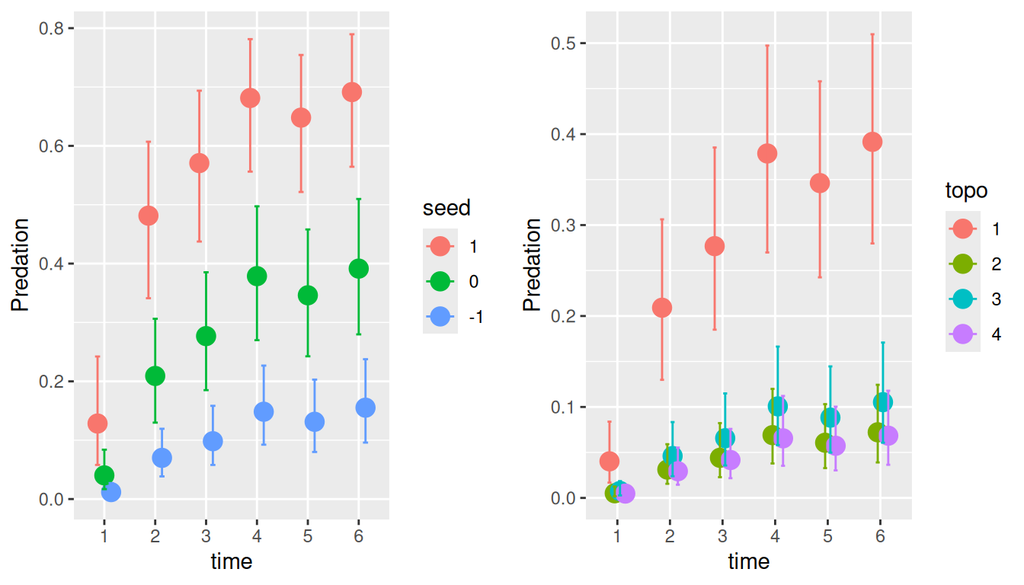

```r
p1 = plot(conditional_effects(df.seed.3,
                              effect="time:seed"), # topo at reference level
          plot=F)

p2 = plot(conditional_effects(df.seed.3,
                              effect="time:topo"), # seed at mean=0
          plot=F)
plot_grid(p1[[1]],p2[[1]])
```

It already looks like predation rate is pretty constant in the last 3 campaigns.

By specifying `conditions=`, we can redo these plots for all levels of the 3rd predictor.

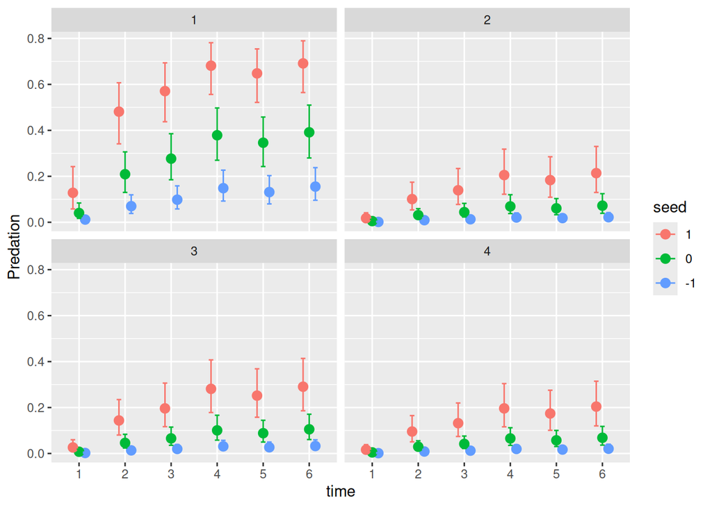

```r
plot(conditional_effects(df.seed.3,
                         effect="time:seed",
                         conditions = make_conditions(df.seed.3,vars=c("topo"))))
```

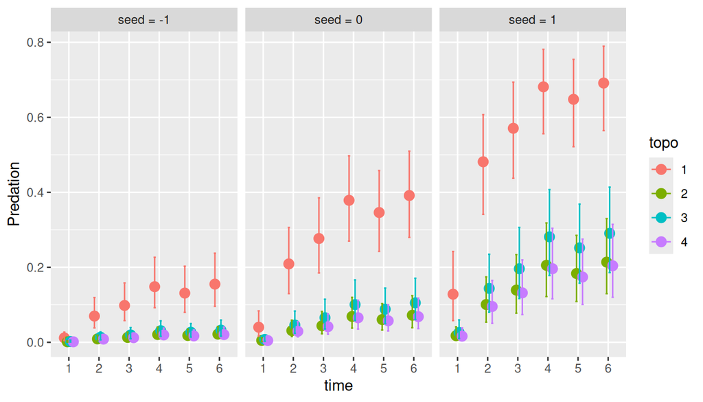

```r
plot(conditional_effects(df.seed.3,
                         effect="time:topo",
                         conditions = make_conditions(df.seed.3,vars=c("seed"))))
```

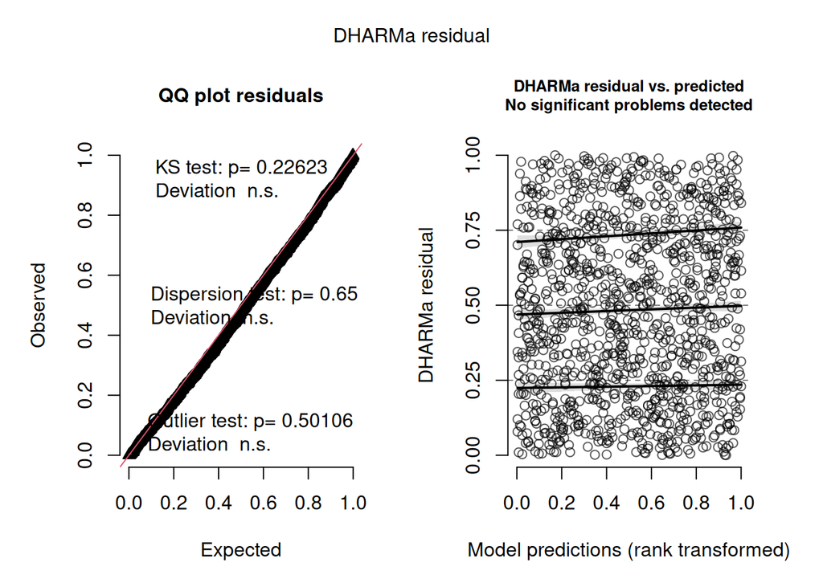

```r
dh_check_brms(df.seed.3)
```

Model comparison reveals that predation rate changes over time.

```r
LOO(df.seed.1, df.seed.2, df.seed.3)
```

```
          elpd_diff se_diff
df.seed.3   0.0       0.0
df.seed.2 -28.4       5.3
df.seed.1 -68.7      10.8
```

But it still doesn’t answer the question if predation rate reached a stable limit in the last 3 campaigns.

With emmeans, we can extract mean fitted values versus `time`, averaged over the remaing predictors. By default, the output is on linear scale, but it can also be displayed on response scale

```r
emmeans(df.seed.3, ~time)
```

```
 time emmean lower.HPD upper.HPD
 1     -4.66     -5.57     -3.86
 2     -2.83     -3.37     -2.30
 3     -2.46     -2.94     -1.95
 4     -1.99     -2.43     -1.53
 5     -2.13     -2.60     -1.70
 6     -1.94     -2.38     -1.45

Results are averaged over the levels of: topo
Point estimate displayed: median
Results are given on the logit (not the response) scale.
HPD interval probability: 0.95
```

```r
emmeans(df.seed.3, ~time, type="response")
```

```
 time response lower.HPD upper.HPD
 1     0.00934   0.00291    0.0188
 2     0.05570   0.03103    0.0873
 3     0.07878   0.04880    0.1218
 4     0.12035   0.07660    0.1713
 5     0.10606   0.06341    0.1488
 6     0.12567   0.07929    0.1803

Results are averaged over the levels of: topo
Point estimate displayed: median
Results are back-transformed from the logit scale
HPD interval probability: 0.95
```

We could look at pairwise difference between all levels of `time` (all campaigns), but emmeans also can display only consecutive contrasts with `consec~...`

```r
emmeans(df.seed.3, consec~time)
```

```
$emmeans
 time emmean lower.HPD upper.HPD
 1     -4.66     -5.57     -3.86
 2     -2.83     -3.37     -2.30
 3     -2.46     -2.94     -1.95
 4     -1.99     -2.43     -1.53
 5     -2.13     -2.60     -1.70
 6     -1.94     -2.38     -1.45

Results are averaged over the levels of: topo
Point estimate displayed: median
Results are given on the logit (not the response) scale.
HPD interval probability: 0.95

$contrasts
 contrast      estimate lower.HPD upper.HPD
 time2 - time1    1.840     0.902     2.812
 time3 - time2    0.378    -0.287     1.045
 time4 - time3    0.469    -0.132     1.147
 time5 - time4   -0.150    -0.770     0.451
 time6 - time5    0.190    -0.424     0.817

Results are averaged over the levels of: topo
Point estimate displayed: median
Results are given on the log odds ratio (not the response) scale.
HPD interval probability: 0.95
```

The contrasts between the last 3 campaigns are overlapping 0. So we don’t see evidence for strong differences, especially when we compare it against the effect size of the difference between 1st and 2nd campaign.

Alternatively, you could fit a model `Predation ~ seed + topo + time.combined`, where `time.combined` is the same as `time`, but levels 4,5,6 are combined in 1 level. Then do a model comparison versus the full model.